# Лабораторная работа 3

Имитационное моделирование

Богданюк Анна Васильевна

Российский университет дружбы народов

# Вводная часть

## Цель работы

Целью данной лабораторной работы является создание агентных моделей, где агенты - это маргаритки двух типов — чёрные (black) и белые (white) (Модель Daisyworld).

# Основная часть

## Модель Daisyworld

Если температура становится слишком высокой или слишком низкой, маргаритки не захотят размножаться. Пока температура благоприятна, маргаритки конкурируют за землю и пытаются дать начало новому растению в местах, расположенных неподалёку от них. Когда климат слишком холодный, черным маргариткам необходимо размножаться, чтобы повысить температуру, и наоборот — когда климат слишком теплый, необходимо производить больше белых маргариток, чтобы охладить климат.

## Модель Daisyworld

Взаимодействие живых и неживых аспектов этого мира находит равновесие в широком диапазоне параметров, хотя при достаточно сильном внешнем воздействии маргаритки не смогут регулировать температуру планеты и в конечном итоге вымрут.

## Описание модели Daisyworld

В модели Daisyworld агентами являются чёрные и белые маргаритки. Они живут на клеточной сетке (среда). Свойства агентов: вид и возраст.

## Правила

— Маргаритки изменяют локальную температуру за счёт разного альбедо. — Температура влияет на вероятность размножения (чем ближе к оптимуму, тем выше шанс заселить соседнюю пустую клетку). — Агенты стареют и умирают после определённого возраста. — Среда (температура) диффундирует между клетками.

## Параметры

— luminosity – солнечная постоянная (может изменяться со временем). — albedo_black, albedo_white – альбедо чёрных и белых маргариток. — surface_albedo — альбедо пустой почвы. — max_age — максимальный возраст маргаритки.

## Выполнение работы

Создаём рабочее пространство для работы (рис. 1).

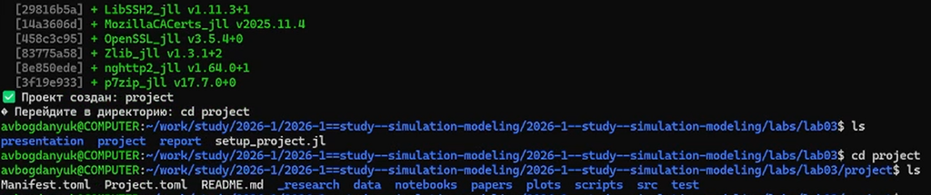

Рисунок 1: Создаём директорию project

## Выполнение работы

Создаю файл src/daisyworld.jl. Здесь мы определим тип агента и функции шага модели (рис. 2).

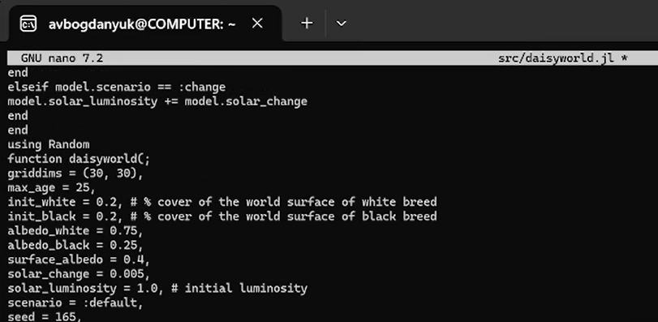

Рисунок 2: Создаём файл src/daisyworld.jl

## Выполнение работы

Сделаем базовую визуализацию. Построим тепловую карту, которая будет представлять собой температуру поверхности модели. Маргаритки будут отображаться черно-белыми в соответствии с их видом. Для этого создадим файл scripts/daisyworld.jl (рис. 3).

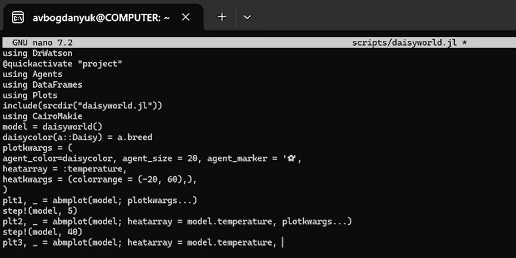

Рисунок 3: Создаём файл scripts/daisyworld.jl

## Выполнение работы

С помощью скрипта tangle.jl создадим производные файлы от scripts/daisyworld.jl, который мы ранее преобразовали в литературном стиле (рис. 4).

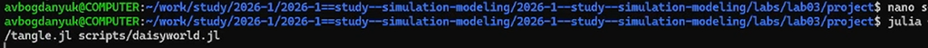

Рисунок 4: Создаём производные файлы

## Выполнение работы

В ходе лабораторной я создала 7 скриптов, с помощью которых мы могли визуально изучить модель Daisyworld, наглядно посмотреть как различные параметры влияют на размножение или погибель маргариток (рис. 5).

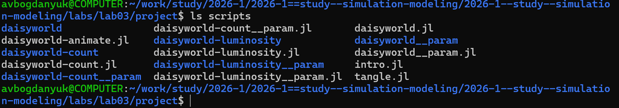

Рисунок 5: Создаём модели

## Выполнение работы

На этом графике мы можем посмотреть как меняется количество маргариток с течением времени (рис. 6).

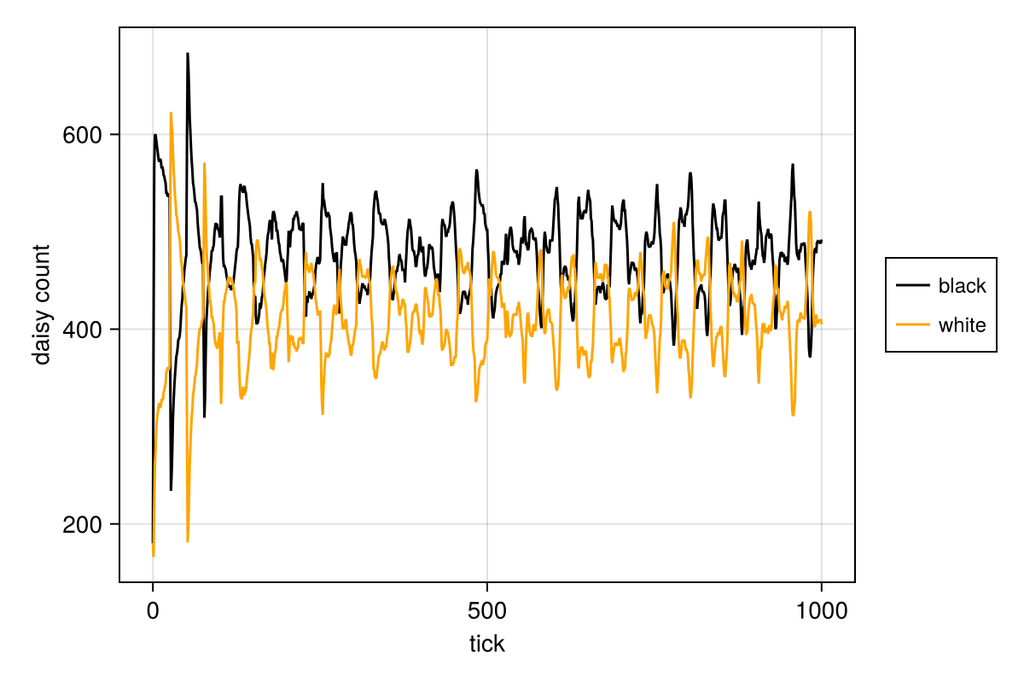

Рисунок 6: График количества маргариток

## Выполнение работы

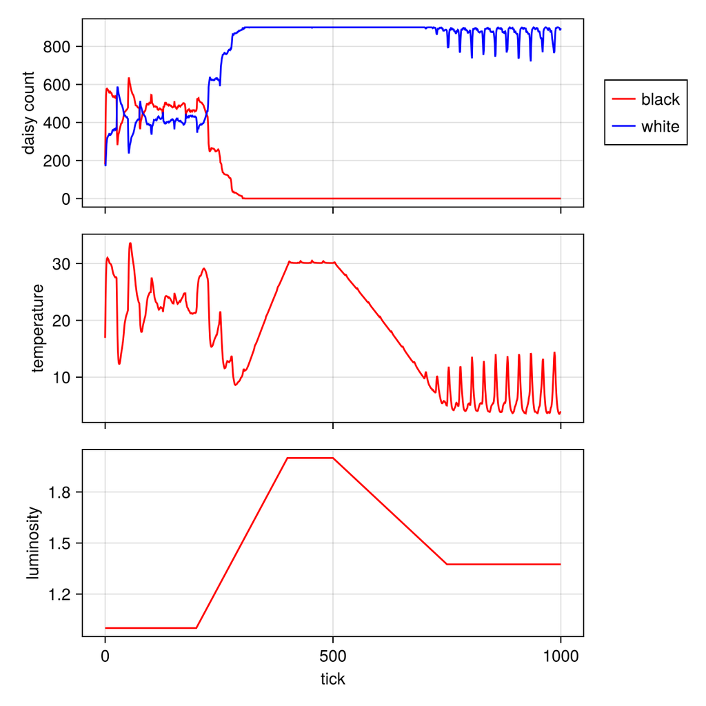

Рисунок 7: Комплексный график

## Выполнение работы

Тепловая карта, которая представляет собой температуру поверхности модели. Маргаритки отображаются черно-белыми в соответствии с их видом. (рис. 8).

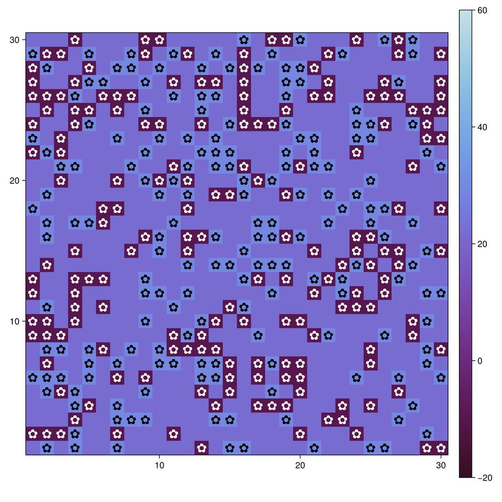

Рисунок 8: Тепловая карта на первом шаге

## Выводы

В ходе выполнения лабораторной работы были созданы агентные модели, где агенты - это маргаритки двух типов — чёрные (black) и белые (white) (Модель Daisyworld).

## Список литературы

1. . Watson A. J., Lovelock J. E. Biological homeostasis of the global environment: the parable of Daisyworld // Tellus B: Chemical and Physical Meteorology. — 1983. — Jan. — Vol. 35, no. 4. — P. 284. — ISSN 0280-6509. — DOI: 10.3402/tellusb.v35i4.14616.